# Air Quality in Southampton (UK)

Exploring the effect of UK covid 19 lockdown on air quality: Summary for BBC South

Ben Anderson (b.anderson@soton.ac.uk `@dataknut`)

Last run at: 2020-06-18 21:55:01 (Europe/London)

# 1 Introduction

This report describes exploratory analysis of changes in air quality in the City of Southampton, UK in Spring 2020.

```r
lastHA <- max(fixedDT[source == "hantsAir"]$dateTimeUTC)
diffHA <- lubridate::now() - lastHA
lastAURN <- max(fixedDT[source == "AURN"]$dateTimeUTC)
diffAURN <- lubridate::now() - lastAURN
```

Data for Southampton downloaded from :

- http://www.hantsair.org.uk/hampshire/asp/Bulletin.asp?la=Southampton (see also https://www.southampton.gov.uk/environmental-issues/pollution/air-quality/);
- https://uk-air.defra.gov.uk/networks/network-info?view=aurn

Southampton City Council collects various forms of air quality data at the sites shown in Table 2.1. The data is available in raw form from http://www.hantsair.org.uk/hampshire/asp/Bulletin.asp?la=Southampton&bulletin=daily&site=SH5.

Some of these sites feed data to [AURN](https://uk-air.defra.gov.uk/networks/network-info?view=aurn). The data that goes via AURN is [ratified](https://uk-air.defra.gov.uk/assets/documents/Data_Validation_and_Ratification_Process_Apr_2017.pdf) to check for outliers and instrument/measurement error. AURN data less than six months old has not undergone this process. AURN data is (c) Crown 2020 copyright Defra and available for re-use via https://uk-air.defra.gov.uk, licenced under the [Open Government Licence](http://www.nationalarchives.gov.uk/doc/open-government-licence/version/2/) (OGL).

# 2 Data

In this report we use data from the following sources:

- http://www.hantsair.org.uk/hampshire/asp/Bulletin.asp?la=Southampton last updated at 2020-06-08 10:00:00;
- https://uk-air.defra.gov.uk/networks/network-info?view=aurn last updated at 2020-06-07 23:00:00.

```r
t <- fixedDT[!is.na(value), .(nObs = .N, firstData = min(dateTimeUTC), latestData = max(dateTimeUTC), nMeasures = uniqueN(pollutant)),
    keyby = .(site, source)]

kableExtra::kable(t, caption = "Sites, data source and number of valid observations. note that measures includes wind speed and direction in the AURN sourced data",
    digits = 2) %>% kable_styling()
```

Table 2.1: Sites, data source and number of valid observations. note that measures includes wind speed and direction in the AURN sourced data

| site | source | nObs | firstData | latestData | nMeasures |
| --- | --- | --- | --- | --- | --- |
| Southampton - A33 Roadside (near docks, AURN site) | hantsAir | 85918 | 2017-01-01 00:00:00 | 2020-06-08 10:00:00 | 3 |
| Southampton - Background (near city centre, AURN site) | hantsAir | 162148 | 2017-01-25 11:00:00 | 2020-06-08 10:00:00 | 6 |
| Southampton - Onslow Road (near RSH) | hantsAir | 82232 | 2017-01-01 00:00:00 | 2020-04-15 07:00:00 | 3 |
| Southampton - Victoria Road (Woolston) | hantsAir | 60078 | 2017-01-01 00:00:00 | 2020-04-01 06:00:00 | 3 |
| Southampton A33 (via AURN) | AURN | 220010 | 2017-01-01 00:00:00 | 2020-06-07 23:00:00 | 8 |
| Southampton Centre (via AURN) | AURN | 343216 | 2017-01-01 00:00:00 | 2020-06-07 23:00:00 | 13 |

Table 2.2 shows the poillutants recorded at each site.

```r
t <- with(fixedDT[!is.na(value)], table(pollutant, site))

kableExtra::kable(t, caption = "Sites, pollutant and number of valid observations", digits = 2) %>% kable_styling()
```

Table 2.2: Sites, pollutant and number of valid observations

|  | Southampton - A33 Roadside (near docks, AURN site) | Southampton - Background (near city centre, AURN site) | Southampton - Onslow Road (near RSH) | Southampton - Victoria Road (Woolston) | Southampton A33 (via AURN) | Southampton Centre (via AURN) |
| --- | --- | --- | --- | --- | --- | --- |
| no | 29055 | 28702 | 27412 | 20026 | 29641 | 28657 |
| no2 | 29020 | 28702 | 27408 | 20026 | 29640 | 28657 |
| nox | 0 | 22877 | 27412 | 20026 | 29640 | 28658 |
| nv10 | 0 | 0 | 0 | 0 | 23208 | 21105 |
| nv2.5 | 0 | 0 | 0 | 0 | 0 | 22627 |
| o3 | 0 | 0 | 0 | 0 | 0 | 28645 |
| pm10 | 27843 | 26124 | 0 | 0 | 25681 | 26180 |
| pm2.5 | 0 | 27632 | 0 | 0 | 0 | 27702 |
| so2 | 0 | 0 | 0 | 0 | 0 | 28261 |
| sp2 | 0 | 28111 | 0 | 0 | 0 | 0 |
| v10 | 0 | 0 | 0 | 0 | 23208 | 21105 |
| v2.5 | 0 | 0 | 0 | 0 | 0 | 22627 |
| wd | 0 | 0 | 0 | 0 | 29496 | 29496 |
| ws | 0 | 0 | 0 | 0 | 29496 | 29496 |

```r
fixedDT <- fixedDT[!(site %like% "AURN site")]

t <- fixedDT[!is.na(value), .(nObs = .N, nPollutants = uniqueN(pollutant), lastDate = max(dateTimeUTC)), keyby = .(site,
    source)]

kableExtra::kable(t, caption = "Sites, data source and number of valid observations", digits = 2) %>% kable_styling()
```

Table 2.3: Sites, data source and number of valid observations

| site | source | nObs | nPollutants | lastDate |
| --- | --- | --- | --- | --- |
| Southampton - Onslow Road (near RSH) | hantsAir | 82232 | 3 | 2020-04-15 07:00:00 |
| Southampton - Victoria Road (Woolston) | hantsAir | 60078 | 3 | 2020-04-01 06:00:00 |
| Southampton A33 (via AURN) | AURN | 220010 | 8 | 2020-06-07 23:00:00 |
| Southampton Centre (via AURN) | AURN | 343216 | 13 | 2020-06-07 23:00:00 |

We use this data to compare:

- pre and during-lockdown air quality measures
- air quality measures during lockdown 2020 with average measures for the same time periods in the preceding 3 years (2017-2019)

Further, air quality is not wholly driven by sources that lockdown might suppress and indeed that suppression may lead to rebound affects. For example we might expect more emissions due to increased domestic heating during cooler lockdown periods. As a result the analysis presented below must be considered a preliminary ‘before meteorological adjustment’ and ‘before controlling for other sources’ analysis of the affect of lockdown on air quality in Southampton.

For much more detailed analysis see a longer and very messy [data report](https://dataknut.github.io/airQual/sccAirQualExplore_Exploring%20the%20SSC%20and%20AURN%20data.html).

# 3 WHO air quality thresholds

- https://www.who.int/news-room/fact-sheets/detail/ambient-(outdoor)-air-quality-and-health

# 4 Nitrogen Dioxide (no2)

```r
yLab <- "Nitrogen Dioxide (ug/m3)"
no2dt <- fixedDT[pollutant == "no2"]
```

Figure 4.1 shows the NO2 trend over time. Is lockdown below trend?

```r
no2dt[, `:=`(date, as.Date(dateTimeUTC))]  # set date to date for this one

oaNO2 <- openair::TheilSen(no2dt[date < as.Date("2020-06-01")], "value", ylab = "NO2", deseason = TRUE, xlab = "Year",
    date.format = "%Y", date.breaks = 4)
```

```
## [1] "Taking bootstrap samples. Please wait."
```

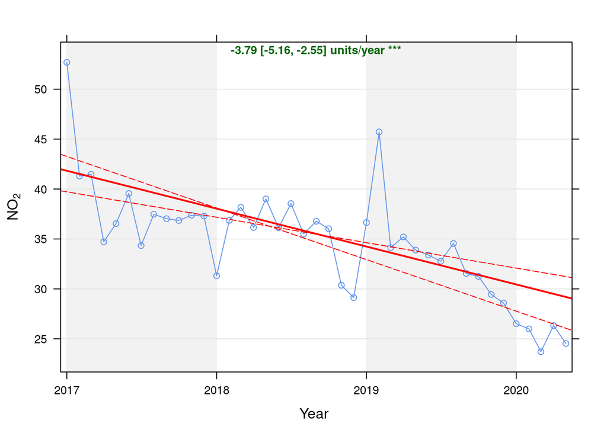

Figure 4.1: Theil-Sen trend (NO2)

```r
p <- oaNO2$plot

getModelTrendTable <- function(oa, fname) {
    # oa is an openAir object created by theilSen calculates the % below trend using the theil sen slope line
    # parameters oa <- oaGWh
    oaData <- as.data.table(oa$data$main.data)
    rDT <- oaData[, .(date, conc, a, b, slope)]
    # https://github.com/davidcarslaw/openair/blob/master/R/TheilSen.R#L192 and
    # https://github.com/davidcarslaw/openair/blob/master/R/TheilSen.R#L625
    rDT[, `:=`(x, time_length(date - as.Date("1970-01-01"), unit = "days"))]  # n days since x = 0
    rDT[, `:=`(expectedVal, a + (b * x))]  # b = slope / 365

    # checks
    p <- ggplot2::ggplot(rDT, aes(x = date)) + geom_line(aes(y = conc)) + labs(y = "Value", caption = fname)
    p <- p + geom_line(aes(y = expectedVal), linetype = "dashed")
    ggplot2::ggsave(here::here("docs", "plots", paste0("SSC_trendModelTestPlot_", fname, ".png")))
    rDT[, `:=`(diff, conc - expectedVal)]
    rDT[, `:=`(pcDiff, (diff/expectedVal) * 100)]

    t <- rDT[, .(date, conc, a, b, slope, expectedVal, diff, pcDiff)]
    return(t)
}

t <- getModelTrendTable(oaNO2, fname = "NO2")

ft <- dcast(t[date >= as.Date("2020-01-01") & date < as.Date("2020-06-01")], date ~ ., value.var = c("diff", "pcDiff"))
ft[, `:=`(date, format.Date(date, format = "%b %Y"))]
kableExtra::kable(ft, caption = "Units and % above/below expected", digits = 2) %>% kable_styling()
```

Table 4.1: Units and % above/below expected

| date | diff | pcDiff |
| --- | --- | --- |
| Jan 2020 | -3.93 | -12.91 |
| Feb 2020 | -4.13 | -13.70 |
| Mar 2020 | -6.11 | -20.49 |
| Apr 2020 | -3.17 | -10.75 |
| May 2020 | -4.65 | -15.94 |

# 5 Oxides of Nitrogen (nox)

```r
yLab <- "Oxides of Nitrogen (ug/m3)"
noxdt <- fixedDT[pollutant == "nox"]
```

Figure 5.1 shows the NOx trend over time. Is lockdown below trend?

```r
noxdt[, `:=`(date, as.Date(dateTimeUTC))]  # set date to date for this one

oaNOx <- openair::TheilSen(noxdt[date < as.Date("2020-06-01")], "value", ylab = "NOx", deseason = TRUE, xlab = "Year",
    date.format = "%Y", date.breaks = 4)
```

```
## [1] "Taking bootstrap samples. Please wait."
```

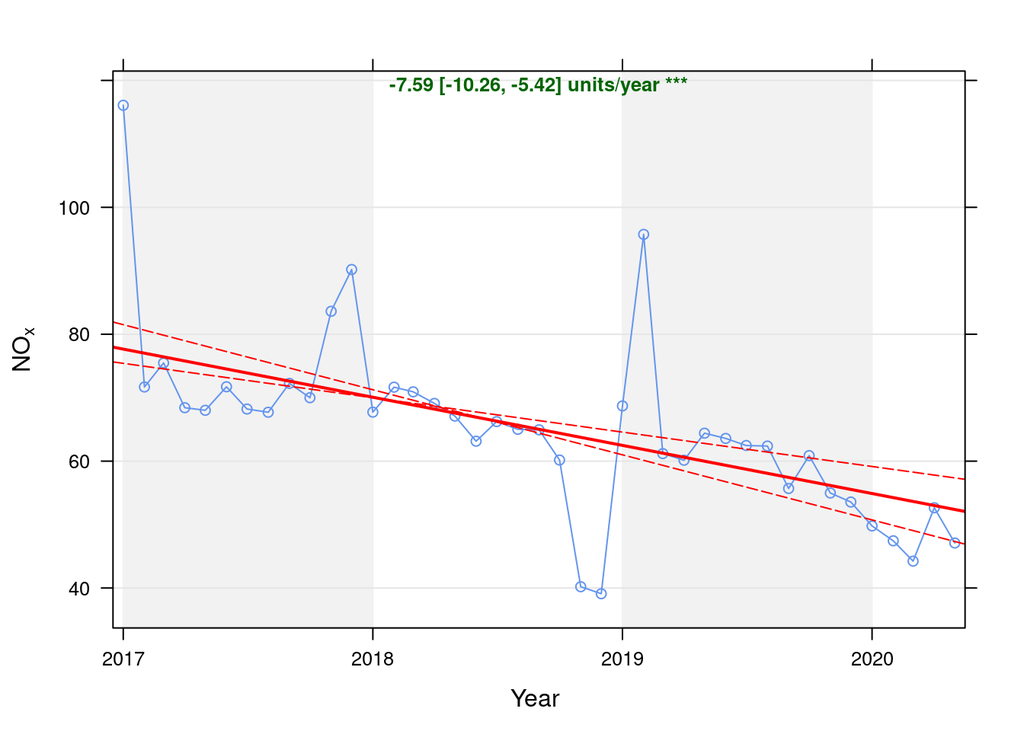

Figure 5.1: Theil-Sen trend (NOx)

```r
p <- oaNOx$plot

t <- getModelTrendTable(oaNOx, fname = "NOx")

ft <- dcast(t[date >= as.Date("2020-01-01") & date < as.Date("2020-06-01")], date ~ ., value.var = c("diff", "pcDiff"))
ft[, `:=`(date, format.Date(date, format = "%b %Y"))]
kableExtra::kable(ft, caption = "Units and % above/below expected", digits = 2) %>% kable_styling()
```

Table 5.1: Units and % above/below expected

| date | diff | pcDiff |
| --- | --- | --- |
| Jan 2020 | -5.11 | -9.30 |
| Feb 2020 | -6.81 | -12.55 |
| Mar 2020 | -9.41 | -17.54 |
| Apr 2020 | -0.35 | -0.66 |
| May 2020 | -5.28 | -10.08 |

# 6 Sulphour Dioxide

```r
yLab <- "Sulphour Dioxide (ug/m3)"
so2dt <- fixedDT[pollutant == "so2"]
```

```r
so2dt[, `:=`(date, as.Date(dateTimeUTC))]  # set date to date for this one

oaSO2 <- openair::TheilSen(noxdt[date < as.Date("2020-06-01")], "value", ylab = "SO2", deseason = TRUE, xlab = "Year",
    date.format = "%Y", date.breaks = 4)
```

```
## [1] "Taking bootstrap samples. Please wait."
```

[figure not shown]

```r
t <- getModelTrendTable(oaSO2, fname = "SO2")

ft <- dcast(t[date >= as.Date("2020-01-01") & date < as.Date("2020-06-01")], date ~ ., value.var = c("diff", "pcDiff"))
ft[, `:=`(date, format.Date(date, format = "%b %Y"))]
kableExtra::kable(ft, caption = "Units and % above/below expected", digits = 2) %>% kable_styling()
```

Table 6.1: Units and % above/below expected

| date | diff | pcDiff |
| --- | --- | --- |
| Jan 2020 | -5.11 | -9.30 |
| Feb 2020 | -6.81 | -12.55 |
| Mar 2020 | -9.41 | -17.54 |
| Apr 2020 | -0.35 | -0.66 |
| May 2020 | -5.28 | -10.08 |

# 7 Ozone

```r
yLab <- "Ozone (ug/m3)"
o3dt <- fixedDT[pollutant == "o3"]
```

Figure 7.1 shows the O3 trend over time. Is lockdown below trend?

```r
o3dt[, `:=`(date, as.Date(dateTimeUTC))]  # set date to date for this one

oaO3 <- openair::TheilSen(o3dt[date < as.Date("2020-06-01")], "value", ylab = "O3", deseason = TRUE, xlab = "Year",
    date.format = "%Y", date.breaks = 4)
```

```
## [1] "Taking bootstrap samples. Please wait."
```

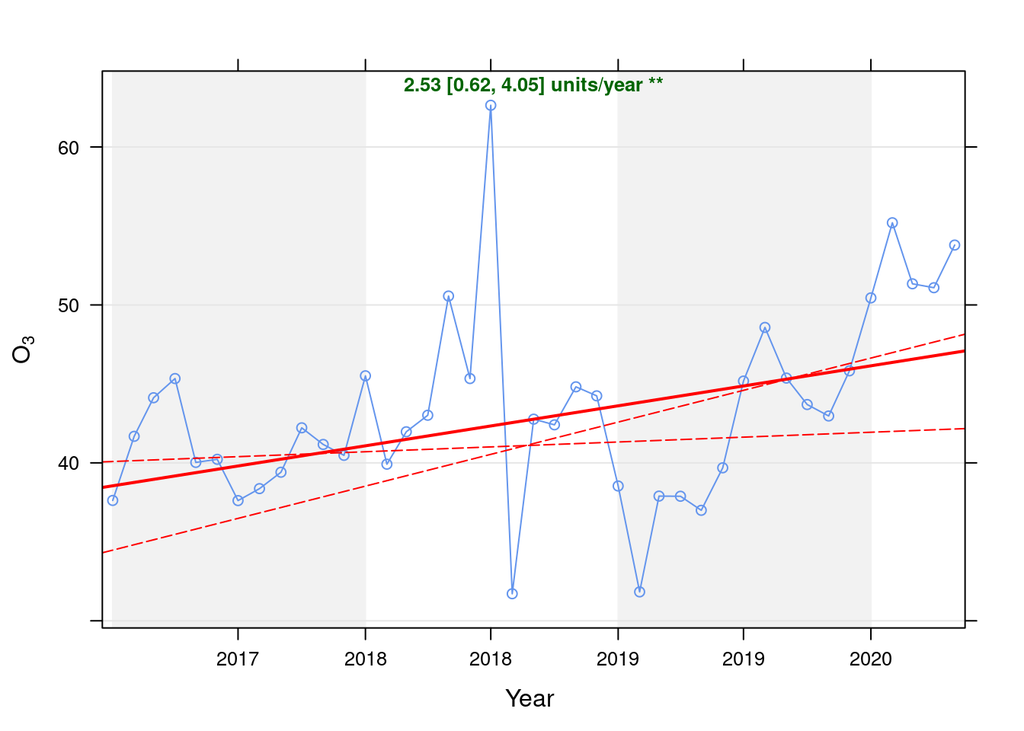

Figure 7.1: Theil-Sen trend (O3)

```r
t <- getModelTrendTable(oaO3, fname = "O3")

ft <- dcast(t[date >= as.Date("2020-01-01") & date < as.Date("2020-06-01")], date ~ ., value.var = c("diff", "pcDiff"))
ft[, `:=`(date, format.Date(date, format = "%b %Y"))]
kableExtra::kable(ft, caption = "Units and % above/below expected", digits = 2) %>% kable_styling()
```

Table 7.1: Units and % above/below expected

| date | diff | pcDiff |
| --- | --- | --- |
| Jan 2020 | 4.30 | 9.31 |
| Feb 2020 | 8.84 | 19.07 |
| Mar 2020 | 4.77 | 10.25 |
| Apr 2020 | 4.31 | 9.22 |
| May 2020 | 6.80 | 14.48 |

# 8 PM 10

```r
yLab <- "PM 10 (ug/m3)"
pm10dt <- fixedDT[pollutant == "pm10"]
```

Figure 8.1 shows the PM10 trend over time. Is lockdown below trend?

```r
pm10dt[, `:=`(date, as.Date(dateTimeUTC))]  # set date to date for this one

oaPM10 <- openair::TheilSen(pm10dt[date < as.Date("2020-06-01")], "value", ylab = "PM10", deseason = TRUE, xlab = "Year",
    date.format = "%Y", date.breaks = 4)
```

```
## [1] "Taking bootstrap samples. Please wait."
```

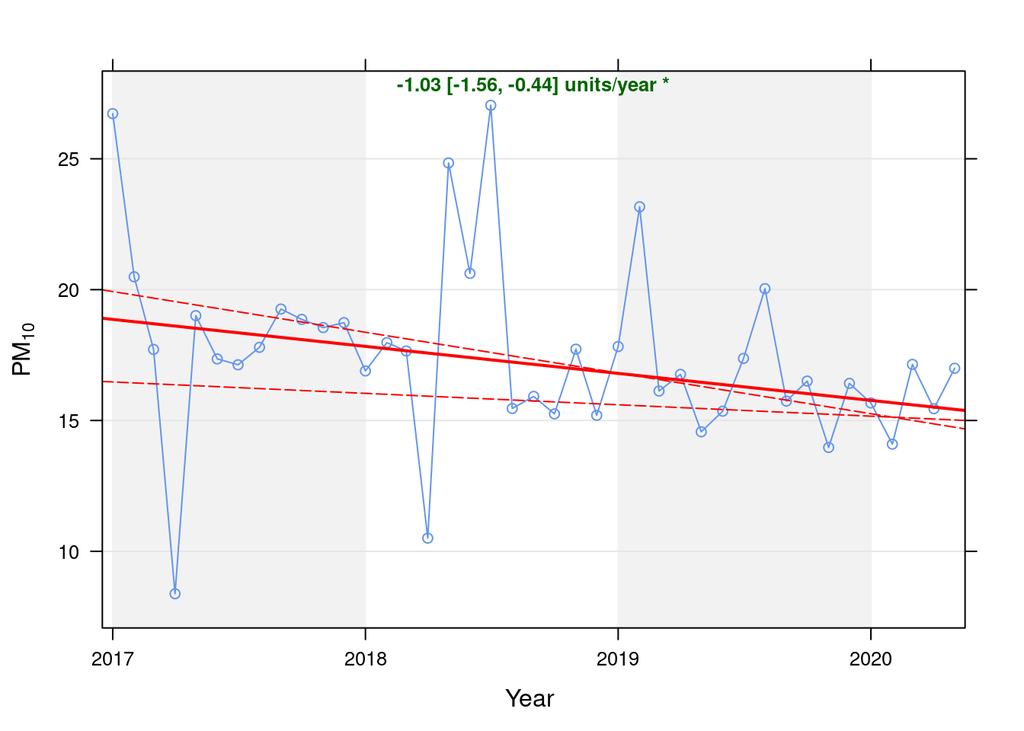

Figure 8.1: Theil-Sen trend (PM10)

```r
t <- getModelTrendTable(oaPM10, fname = "SPM10")

ft <- dcast(t[date >= as.Date("2020-01-01") & date < as.Date("2020-06-01")], date ~ ., value.var = c("diff", "pcDiff"))
ft[, `:=`(date, format.Date(date, format = "%b %Y"))]
kableExtra::kable(ft, caption = "Units and % above/below expected", digits = 2) %>% kable_styling()
```

Table 8.1: Units and % above/below expected

| date | diff | pcDiff |
| --- | --- | --- |
| Jan 2020 | -0.10 | -0.62 |
| Feb 2020 | -1.58 | -10.10 |
| Mar 2020 | 1.55 | 9.91 |
| Apr 2020 | -0.06 | -0.38 |
| May 2020 | 1.57 | 10.19 |

# 9 PM 2.5

```r
yLab <- "PM 2.5 (ug/m3)"
pm25dt <- fixedDT[pollutant == "pm2.5"]
```

```r
pm25dt[, `:=`(date, as.Date(dateTimeUTC))]  # set date to date for this one

oaPM25 <- openair::TheilSen(pm25dt[date < as.Date("2020-06-01")], "value", ylab = "PM2.5", deseason = TRUE, xlab = "Year",
    date.format = "%Y", date.breaks = 4)
```

```
## [1] "Taking bootstrap samples. Please wait."
```

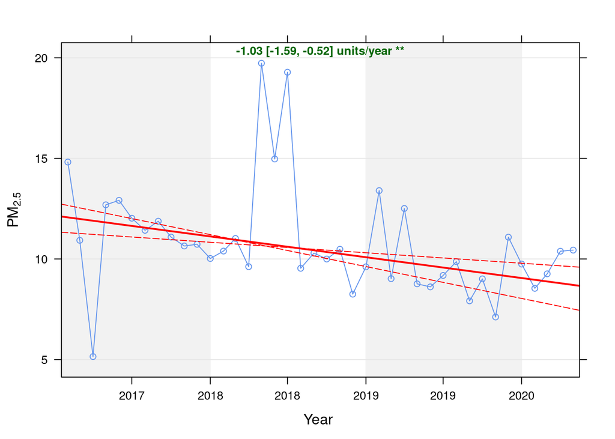

Figure 9.1: Theil-Sen trend (PM2.5)

```r
t <- getModelTrendTable(oaPM25, fname = "PM2.5")

ft <- dcast(t[date >= as.Date("2020-01-01") & date < as.Date("2020-06-01")], date ~ ., value.var = c("diff", "pcDiff"))
ft[, `:=`(date, format.Date(date, format = "%b %Y"))]
kableExtra::kable(ft, caption = "Units and % above/below expected", digits = 2) %>% kable_styling()
```

Table 9.1: Units and % above/below expected

| date | diff | pcDiff |
| --- | --- | --- |
| Jan 2020 | 0.70 | 7.70 |
| Feb 2020 | -0.42 | -4.72 |
| Mar 2020 | 0.38 | 4.27 |
| Apr 2020 | 1.59 | 18.11 |
| May 2020 | 1.73 | 19.89 |

# 10 About

## 10.1 Code

Source:

- https://github.com/dataknut/airQual

History:

- https://github.com/dataknut/airQual/commits/master

## 10.2 Comments and feedback

If you wish to comment please open an issue:

- https://github.com/dataknut/airQual/issues

## 10.3 Citation

If you wish to refer to any of the material from this report please cite as:

- Anderson, B., (2020) Air Quality in Southampton (UK): Exploring the effect of UK covid 19 lockdown on air quality: Summary for BBC South , [Sustainable Energy Research Group](http://www.energy.soton.ac.uk), University of Southampton: Southampton, UK.

Report circulation:

- Public

This work is (c) 2020 the University of Southampton and is part of a collection of [air quality](https://dataknut.github.io/airQual/) data analyses.

# 11 Runtime

Report generated using knitr in [RStudio](http://www.rstudio.com) with R version 3.6.0 (2019-04-26) running on x86_64-redhat-linux-gnu (#1 SMP Thu May 7 19:30:37 EDT 2020).

```r
t <- proc.time() - myParams$startTime

elapsed <- t[[3]]
```

Analysis completed in 14.13 seconds ( 0.24 minutes).

R packages used in this report:

- data.table - (Dowle et al. 2015)
- ggplot2 - (Wickham 2009)
- here - (Müller 2017)
- kableExtra - (Zhu 2019)
- lubridate - (Grolemund and Wickham 2011)
- openAir - (Carslaw and Ropkins 2012)
- skimr - (Arino de la Rubia et al. 2017)
- viridis - (Garnier 2018)

# References

Arino de la Rubia, Eduardo, Hao Zhu, Shannon Ellis, Elin Waring, and Michael Quinn. 2017. *Skimr: Skimr*. https://github.com/ropenscilabs/skimr.

Carslaw, David C., and Karl Ropkins. 2012. “Openair — an R Package for Air Quality Data Analysis.” *Environmental Modelling & Software* 27–28 (0): 52–61. doi:10.1016/j.envsoft.2011.09.008.

Dowle, M, A Srinivasan, T Short, S Lianoglou with contributions from R Saporta, and E Antonyan. 2015. *Data.table: Extension of Data.frame*. https://CRAN.R-project.org/package=data.table.

Garnier, Simon. 2018. *Viridis: Default Color Maps from ’Matplotlib’*. https://CRAN.R-project.org/package=viridis.

Grolemund, Garrett, and Hadley Wickham. 2011. “Dates and Times Made Easy with lubridate.” *Journal of Statistical Software* 40 (3): 1–25. http://www.jstatsoft.org/v40/i03/.

Müller, Kirill. 2017. *Here: A Simpler Way to Find Your Files*. https://CRAN.R-project.org/package=here.

Wickham, Hadley. 2009. *Ggplot2: Elegant Graphics for Data Analysis*. Springer-Verlag New York. http://ggplot2.org.

Zhu, Hao. 2019. *KableExtra: Construct Complex Table with ’Kable’ and Pipe Syntax*. https://CRAN.R-project.org/package=kableExtra.